# TCGA preparation

Joaquim Aguirre-Plans

3/9/2022

## Description

Analyze TCGA dataset from GDC.

```r
library(data.table)
library(dplyr)
library(forcats)
library(ggplot2)
require(magrittr)
library(tidyr)
library(igraph)
library(rjson)
set.seed(1510)
`%ni%` <- Negate(`%in%`)
```

```r
# Define type of counts used
type_counts = "reads" # tpm, reads

# Define working directories
gdc_dir = '/work/ccnr/j.aguirreplans/Databases/TCGA/2022-11-18-Dataset/TCGA'
input_dir = paste(gdc_dir, 'raw', sep='/')
data_dir = paste(input_dir, 'data', sep='/')
metadata_dir = paste(input_dir, 'metadata', sep='/')
additional_dir = paste(input_dir, 'additional', sep='/')
output_dir = paste(gdc_dir, 'out', type_counts, sep='/')
```

## Metadata

Let’s analyze the `metadata.txt` file:

```r
metadata_file = paste(metadata_dir, 'metadata.txt', sep='/')
metadata_df = fread(metadata_file, header=TRUE)
glimpse(metadata_df)
```

```
## Rows: 11,123
## Columns: 47
## $ id                        <chr> "2081a155-9d2d-41f6-b243-68a12e9b342a", "038…
## $ data_format               <chr> "TSV", "TSV", "TSV", "TSV", "TSV", "TSV", "T…
## $ access                    <chr> "open", "open", "open", "open", "open", "ope…
## $ file_name                 <chr> "62ca3ce8-77f9-4e02-ace4-af79519b53fd.rna_se…
## $ submitter_id              <chr> "a94013bf-969c-4bcb-a0fc-17e73864fe82", "291…
## $ data_category             <chr> "Transcriptome Profiling", "Transcriptome Pr…
## $ type                      <chr> "gene_expression", "gene_expression", "gene_…
## $ file_size                 <int> 4244011, 4249531, 4243155, 4240504, 4249297,…
## $ created_datetime          <dttm> 2021-12-14 04:28:51, 2021-12-14 04:19:28, 2…
## $ md5sum                    <chr> "0c6a23a41efb2dc0b10900228ccc500f", "ed90acd…
## $ updated_datetime          <dttm> 2022-01-19 18:00:30, 2022-01-19 18:00:30, 2…
## $ file_id                   <chr> "2081a155-9d2d-41f6-b243-68a12e9b342a", "038…
## $ data_type                 <chr> "Gene Expression Quantification", "Gene Expr…
```

[output cut: 34 more lines]

There are 11123 unique file names, 11123 unique file IDs and 10261 unique participant IDs, meaning that there are participants that are mapped to multiple files.

Here we can observe how most of the samples that belong to the same participant correspond to samples extracted from both tumor and normal tissue:

```r
metadata_with_distinct_counts_per_sample_type = metadata_df %>% select(file_id, participant, sample_type_simplified) %>% unique() %>% group_by(participant) %>% mutate(num_samples_tumor=sum(sample_type_simplified == "tumor")) %>% mutate(num_samples_normal=sum(sample_type_simplified == "normal")) %>% ungroup()
table(metadata_with_distinct_counts_per_sample_type$num_samples_tumor, metadata_with_distinct_counts_per_sample_type$num_samples_normal, dnn=c("num_samples_tumor", "num_samples_normal"))
```

```
##                  num_samples_normal
## num_samples_tumor    0    1
##                 0    0   30
##                 1 9429 1368
##                 2  138   24
##                 3   90   40
##                 4    4    0
```

```r
metadata_with_distinct_counts = metadata_df %>% select(file_id, participant, sample_type) %>% unique() %>% group_by(participant) %>% mutate(num_sample_types_per_participant=n_distinct(sample_type)) %>% mutate(num_samples_per_participant=n_distinct(file_id)) %>% ungroup()
table(metadata_with_distinct_counts$num_samples_per_participant, metadata_with_distinct_counts$num_sample_types_per_participant, dnn=c("num_samples_per_participant", "num_sample_types_per_participant"))
```

```
##                            num_sample_types_per_participant
## num_samples_per_participant    1    2    3
##                           1 9459    0    0
##                           2   16 1490    0
##                           3   69   33   12
##                           4    0   44    0
```

```r
head(metadata_df %>% group_by(participant) %>% filter(n()>1) %>% ungroup() %>% select(file_id, entity_submitter_id, participant, sample_code, portion_code, sample_type, project_id)) %>% arrange(participant)
```

```
## # A tibble: 6 × 7
##   file_id      entity_submitte… participant sample_code portion_code sample_type
##   <chr>        <chr>            <chr>       <chr>       <chr>        <chr>
## 1 35cfd54c-8c… TCGA-CU-A0YR-01… A0YR        01A         12R          Primary Tu…
## 2 0d50ca90-4d… TCGA-BL-A13J-01… A13J        01A         11R          Primary Tu…
## 3 86b7ddd7-1c… TCGA-BH-A204-11… A204        11A         53R          Solid Tiss…
## 4 74e5163f-20… TCGA-BT-A20Q-01… A20Q        01A         11R          Primary Tu…
## 5 51526f32-bb… TCGA-BT-A20U-01… A20U        01A         11R          Primary Tu…
## 6 ed0715a2-f2… TCGA-K4-A3WV-01… A3WV        01A         11R          Primary Tu…
## # … with 1 more variable: project_id <chr>
```

However, there is still a small number of samples that might belong to the same participant and also come from the same type of tissue. In these cases, the sample information might come from different samples, vials, portions or plates. See this website for more information: https://docs.gdc.cancer.gov/Encyclopedia/pages/TCGA_Barcode/

```r
head(metadata_df %>% select(file_id, entity_submitter_id, participant, sample, sample_code, portion_code, plate, center, sample_type, project_id) %>% unique() %>% group_by(participant) %>% filter(n()>1) %>% mutate(num_sample_types_per_participant=n_distinct(sample_type)) %>% mutate(num_samples_per_participant=n_distinct(file_id)) %>% filter((num_sample_types_per_participant == 1 & num_samples_per_participant > 1)) %>% ungroup(), 12)
```

```
## # A tibble: 12 × 12
##    file_id    entity_submitte… participant sample sample_code portion_code plate
##    <chr>      <chr>            <chr>        <int> <chr>       <chr>        <chr>
##  1 dd578d7c-… TCGA-BL-A0C8-01… A0C8             1 01A         11R          A10U
##  2 3c5d447f-… TCGA-BL-A13I-01… A13I             1 01A         11R          A13Y
##  3 23ac8b84-… TCGA-A7-A26J-01… A26J             1 01A         11R          A169
##  4 2b519fff-… TCGA-A7-A26E-01… A26E             1 01A         11R          A169
##  5 50c7c034-… TCGA-A7-A13D-01… A13D             1 01A         13R          A12P
##  6 cc7216dc-… TCGA-HC-8265-01… 8265             1 01A         11R          2263
##  7 95a72aff-… TCGA-HC-8265-01… 8265             1 01B         04R          2302
##  8 fa34c60f-… TCGA-BK-A0CC-01… A0CC             1 01A         21R          A277
##  9 f43d3098-… TCGA-BK-A0CC-01… A0CC             1 01B         04R          A277
## 10 63d0b3c6-… TCGA-BK-A0CC-01… A0CC             1 01A         21R          A16W
## 11 378ab0b2-… TCGA-BK-A26L-01… A26L             1 01C         04R          A277
## 12 a8569b16-… TCGA-BK-A26L-01… A26L             1 01A         11R          A16F
## # … with 5 more variables: center <int>, sample_type <chr>, project_id <chr>,
## #   num_sample_types_per_participant <int>, num_samples_per_participant <int>
```

This means that later, we will have to merge the expression of the samples that are from same participant and come from the same sample type (cancer or normal tissue), but are from different vials, portions or plates. We will do it by using the participant_sample_type code:

```r
if(!("participant_sample_type" %in% colnames(metadata_df))){
  metadata_df$participant_sample_type = paste(metadata_df$participant, metadata_df$sample_type_simplified, sep="-")
  metadata_df %>% fwrite(metadata_file)
  metadata_df = fread(metadata_file, header=TRUE)
}
```

We check that we have the same number of samples and participants for each type of sample:

```r
metadata_df %>% select(participant, participant_sample_type, sample_type_simplified) %>% unique() %>% group_by(sample_type_simplified) %>% summarize(n_participant=n_distinct(participant), n_participant_sample_type=n_distinct(participant_sample_type))
```

```
## # A tibble: 2 × 3
##   sample_type_simplified n_participant n_participant_sample_type
##   <chr>                          <int>                     <int>
## 1 normal                           732                       732
## 2 tumor                          10231                     10231
```

TCGA contains 33 project IDs. Each project is focused on a different type of cancer. Each project contains the following number of participants, depending on the sample type (tumor or normal):

```r
# Remove file IDs and keep only case IDs
metadata_cases_df = metadata_df %>% select(participant, project_id, project_disease_type, sample_type_simplified) %>% unique()

# Get table of project IDs
table(metadata_cases_df$sample_type_simplified, metadata_cases_df$project_id)
```

```
##
##          TCGA-ACC TCGA-BLCA TCGA-BRCA TCGA-CESC TCGA-CHOL TCGA-COAD TCGA-DLBC
##   normal        0        19       113         3         9        41         0
##   tumor        79       406      1095       304        35       456        48
##
##          TCGA-ESCA TCGA-GBM TCGA-HNSC TCGA-KICH TCGA-KIRC TCGA-KIRP TCGA-LAML
##   normal        11        5        44        25        72        32         0
##   tumor        162      161       502        65       532       290       150
##
##          TCGA-LGG TCGA-LIHC TCGA-LUAD TCGA-LUSC TCGA-MESO TCGA-OV TCGA-PAAD
##   normal        0        50        59        49         0       0         4
##   tumor       514       371       516       501        87     378       178
##
##          TCGA-PCPG TCGA-PRAD TCGA-READ TCGA-SARC TCGA-SKCM TCGA-STAD TCGA-TGCT
##   normal         3        52        10         2         1        32         0
##   tumor        179       497       166       259       469       375       150
##
##          TCGA-THCA TCGA-THYM TCGA-UCEC TCGA-UCS TCGA-UVM
##   normal        59         2        35        0        0
##   tumor        504       120       545       57       80
```

We create a table summarizing the number of samples for each cancer type:

```r
summary_n_samples_df = metadata_df %>% select(participant_sample_type, sample_type_simplified, project_id, project_disease_type) %>%
  unique() %>%
  group_by(project_id, project_disease_type, sample_type_simplified) %>%
  summarize(n_samples=n_distinct(participant_sample_type)) %>%
  pivot_wider(names_from = sample_type_simplified, values_from = n_samples) %>%
  mutate(tumor = replace_na(tumor, 0), normal = replace_na(normal, 0))
```

```
## can override using the `.groups` argument.
```

```r
print(summary_n_samples_df)
```

```
## # A tibble: 33 × 4
## # Groups:   project_id, project_disease_type [33]
##    project_id project_disease_type                                  tumor normal
##    <chr>      <chr>                                                 <int>  <int>
##  1 TCGA-ACC   Adrenocortical Carcinoma                                 79      0
##  2 TCGA-BLCA  Bladder Urothelial Carcinoma                            406     19
##  3 TCGA-BRCA  Breast Invasive Carcinoma                              1095    113
##  4 TCGA-CESC  Cervical Squamous Cell Carcinoma and Endocervical Ad…   304      3
##  5 TCGA-CHOL  Cholangiocarcinoma                                       35      9
##  6 TCGA-COAD  Colon Adenocarcinoma                                    456     41
##  7 TCGA-DLBC  Lymphoid Neoplasm Diffuse Large B-cell Lymphoma          48      0
##  8 TCGA-ESCA  Esophageal Carcinoma                                    162     11
##  9 TCGA-GBM   Glioblastoma Multiforme                                 161      5
## 10 TCGA-HNSC  Head and Neck Squamous Cell Carcinoma                   502     44
## # … with 23 more rows
```

```r
summary_n_samples_file = "/home/j.aguirreplans/Projects/Scipher/SampleSize/data/out/tables/tcga_num_samples.txt"
summary_n_samples_df %>% fwrite(summary_n_samples_file)
```

We create a plot summarizing the number of samples for each cancer type:

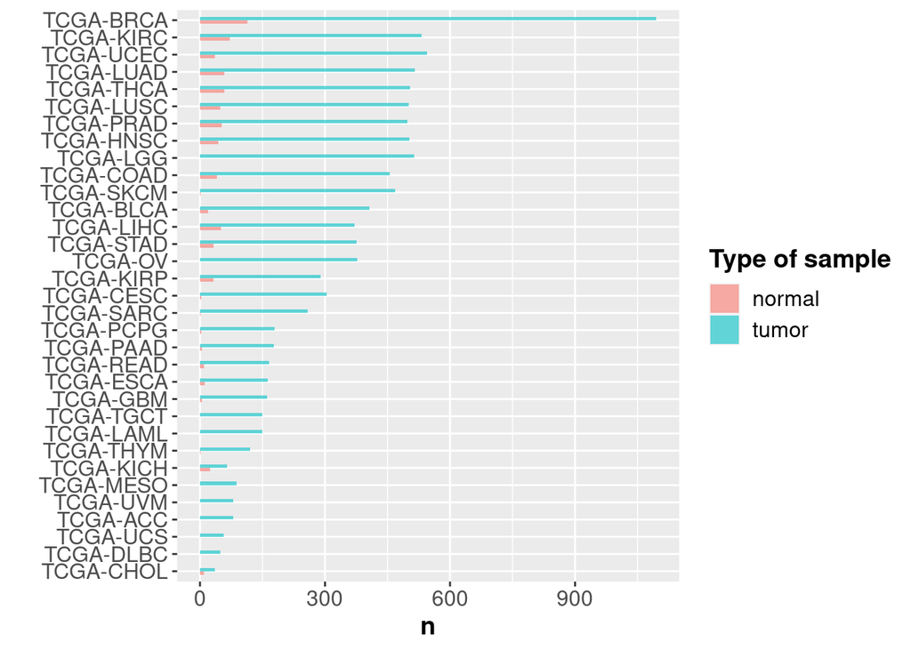

```r
# Plot project IDs
metadata_cases_count_tumor <- metadata_cases_df %>% filter(sample_type_simplified == "tumor") %>% count(project_id)
metadata_cases_count_normal <- metadata_cases_df %>% filter(sample_type_simplified == "normal") %>% count(project_id)
metadata_cases_count_by_sample_type = full_join(metadata_cases_count_tumor %>% rename(tumor=n), metadata_cases_count_normal %>% rename(normal=n), by="project_id") %>% replace(is.na(.), 0) %>% pivot_longer(-project_id, names_to="sample_type_simplified", values_to="n")
metadata_cases_plot <- metadata_cases_count_by_sample_type %>%
  mutate(project_id = fct_reorder(project_id, n)) %>%
  ggplot( aes(x=project_id, y=n, fill=sample_type_simplified)) +
    geom_bar(position="dodge", stat="identity", alpha=.6, width=.4) +
    coord_flip() +
    xlab("") +
    guides(fill=guide_legend(title="Type of sample")) +
    #theme_bw()
    theme(plot.title =  element_text(size = 17, face="bold"), axis.title = element_text(size = 14, face="bold"), axis.text = element_text(size = 12), legend.text = element_text(size = 12), legend.title=element_text(size=14, face="bold"))
metadata_cases_plot_file = '/home/j.aguirreplans/Projects/Scipher/SampleSize/data/out/plots/tcga_num_cases_per_project.png'
ggsave(metadata_cases_plot_file, plot=metadata_cases_plot, type='cairo', dpi = 300, height=8, width = 10)
#ggsave(metadata_cases_plot_file,plot = metadata_cases_plot,type='cairo',dpi = 1200,width = 9000,height = 6000,units = c("px"))

metadata_cases_plot
```

The selected samples come from 139different tissues, 52 tissues from normal samples and 139 tissues from tumor samples.

Let’s try to group normal samples from the same tissue.

First, we group redundant tissues:

```r
# Group redundant tissues
metadata_df = metadata_df %>%
  mutate(tissue_simplified = replace(tissue_or_organ_of_origin, tissue_or_organ_of_origin %in% c("Anterior wall of bladder", "Bladder, NOS", "Bladder neck", "Dome of bladder", "Lateral wall of bladder", "Posterior wall of bladder", "Trigone of bladder", "Ureteric orifice"), "Bladder")) %>%
  mutate(tissue_simplified = replace(tissue_simplified, tissue_or_organ_of_origin %in% c("Cortex of adrenal gland", "Medulla of adrenal gland"), "Adrenal gland")) %>%
  mutate(tissue_simplified = replace(tissue_simplified, tissue_or_organ_of_origin %in% c("Breast, NOS", "Lower-inner quadrant of breast", "Lower-outer quadrant of breast", "Overlapping lesion of breast", "Overlapping lesion of breast", "Upper-inner quadrant of breast", "Upper-outer quadrant of breast"), "Breast")) %>%
  mutate(tissue_simplified = replace(tissue_simplified, ((project_id == "TCGA-BRCA") & (tissue_or_organ_of_origin == "")), "Breast")) %>%
  mutate(tissue_simplified = replace(tissue_simplified, tissue_or_organ_of_origin %in% c("Extrahepatic bile duct", "Intrahepatic bile duct", "Gallbladder"), "Bile duct")) %>%
  mutate(tissue_simplified = replace(tissue_simplified, tissue_or_organ_of_origin %in% c("Ascending colon", "Cecum", "Colon, NOS", "Descending colon", "Hepatic flexure of colon", "Sigmoid colon", "Hepatic flexure of colon", "Sigmoid colon", "Splenic flexure of colon", "Transverse colon", "Rectosigmoid junction", "Rectum, NOS"), "Colon/Rectum")) %>%
  mutate(tissue_simplified = replace(tissue_simplified, ((project_id == "TCGA-COAD") & (tissue_or_organ_of_origin == "")), "Colon/Rectum")) %>%
  mutate(tissue_simplified = replace(tissue_simplified, ((project_id == "TCGA-READ") & ((tissue_or_organ_of_origin == "") | (tissue_or_organ_of_origin == "Unknown primary site"))), "Colon/Rectum")) %>%
  mutate(tissue_simplified = replace(tissue_simplified, tissue_or_organ_of_origin %in% c("Esophagus, NOS", "Lower third of esophagus", "Middle third of esophagus", "Thoracic esophagus", "Upper third of esophagus"), "Esophagus")) %>%
  mutate(tissue_simplified = replace(tissue_simplified, tissue_or_organ_of_origin %in% c("Brain, NOS", "Brain stem", "Cerebrum", "Cerebellum, NOS", "Frontal lobe", "Occipital lobe", "Parietal lobe", "Temporal lobe"), "Brain")) %>%
  mutate(tissue_simplified = replace(tissue_simplified, ((project_id == "TCGA-GBM") & (tissue_or_organ_of_origin == "")), "Brain")) %>%
  mutate(tissue_simplified = replace(tissue_simplified, ((project_id == "TCGA-LGG") & (tissue_or_organ_of_origin == "")), "Brain")) %>%
  mutate(tissue_simplified = replace(tissue_simplified, tissue_or_organ_of_origin %in% c("Anterior floor of mouth", "Base of tongue, NOS", "Border of tongue", "Cheek mucosa", "Floor of mouth, NOS", "Gum, NOS", "Hard palate", "Hypopharynx, NOS", "Larynx, NOS", "Lip, NOS", "Lower gum", "Mandible", "Mouth, NOS", "Oropharynx, NOS", "Overlapping lesion of lip, oral cavity and pharynx", "Palate, NOS", "Pharynx, NOS", "Posterior wall of oropharynx", "Retromolar area", "Supraglottis", "Tongue, NOS", "Tonsil, NOS", "Upper Gum", "Ventral surface of tongue, NOS"), "Mouth/Larynx")) %>%
  mutate(tissue_simplified = replace(tissue_simplified, tissue_or_organ_of_origin %in% c("Kidney, NOS"), "Kidney")) %>%
  mutate(tissue_simplified = replace(tissue_simplified, tissue_or_organ_of_origin %in% c("Liver"), "Liver")) %>%
  mutate(tissue_simplified = replace(tissue_simplified, tissue_or_organ_of_origin %in% c("Lower lobe, lung", "Lung, NOS", "Main bronchus", "Middle lobe, lung", "Upper lobe, lung", "Lower lobe, lung", "Overlapping lesion of lung"), "Lung")) %>%
  mutate(tissue_simplified = replace(tissue_simplified, tissue_or_organ_of_origin %in% c("Nervous system, NOS", "Peripheral nerves and autonomic nervous system of upper limb and shoulder"), "Nervous system")) %>%
  mutate(tissue_simplified = replace(tissue_simplified, tissue_or_organ_of_origin %in% c("Pleura, NOS"), "Pleura")) %>%
  mutate(tissue_simplified = replace(tissue_simplified, tissue_or_organ_of_origin %in% c("Body of pancreas", "Head of pancreas", "Overlapping lesion of pancreas", "Pancreas, NOS", "Tail of pancreas"), "Pancreas")) %>%
  mutate(tissue_simplified = replace(tissue_simplified, tissue_or_organ_of_origin %in% c("Adrenal gland, NOS"), "Adrenal gland")) %>%
  mutate(tissue_simplified = replace(tissue_simplified, tissue_or_organ_of_origin %in% c("Prostate gland"), "Prostate")) %>%
  mutate(tissue_simplified = replace(tissue_simplified, tissue_or_organ_of_origin %in% c("Connective, subcutaneous and other soft tissues, NOS", "Connective, subcutaneous and other soft tissues of abdomen", "Connective, subcutaneous and other soft tissues of head, face, and neck", "Connective, subcutaneous and other soft tissues of lower limb and hip", "Connective, subcutaneous and other soft tissues of pelvis", "Connective, subcutaneous and other soft tissues of thorax", "Connective, subcutaneous and other soft tissues of trunk, NOS", "Connective, subcutaneous and other soft tissues of upper limb and shoulder", "Overlapping lesion of connective, subcutaneous and other soft tissues", "Specified parts of peritoneum", "Retroperitoneum"), "Connective tissue")) %>%
  mutate(tissue_simplified = replace(tissue_simplified, tissue_or_organ_of_origin %in% c("Skin, NOS"), "Skin")) %>%
  mutate(tissue_simplified = replace(tissue_simplified, tissue_or_organ_of_origin %in% c("Body of stomach", "Cardia, NOS", "Fundus of stomach", "Gastric antrum", "Lesser curvature of stomach, NOS", "Pylorus", "Stomach, NOS"), "Stomach")) %>%
  mutate(tissue_simplified = replace(tissue_simplified, tissue_or_organ_of_origin %in% c("Testis, NOS"), "Testis")) %>%
  mutate(tissue_simplified = replace(tissue_simplified, ((project_id == "TCGA-TGCT") & (tissue_or_organ_of_origin == "")), "Testis")) %>%
  mutate(tissue_simplified = replace(tissue_simplified, tissue_or_organ_of_origin %in% c("Thyroid gland"), "Thyroid gland")) %>%
  mutate(tissue_simplified = replace(tissue_simplified, tissue_or_organ_of_origin %in% c("Thymus"), "Thymus")) %>%
  mutate(tissue_simplified = replace(tissue_simplified, tissue_or_organ_of_origin %in% c("Cervix uteri", "Corpus uteri", "Endometrium", "Fundus uteri", "Isthmus uteri", "Uterus, NOS"), "Uterus/Cervix")) %>%
  mutate(tissue_simplified = replace(tissue_simplified, ((project_id == "TCGA-UCEC") & (tissue_or_organ_of_origin == "")), "Uterus/Cervix")) %>%
  mutate(tissue_simplified = replace(tissue_simplified, tissue_or_organ_of_origin %in% c("Choroid", "Ciliary body", "Overlapping lesion of eye and adnexa"), "Eye")) %>%
  mutate(tissue_simplified = replace(tissue_simplified, tissue_or_organ_of_origin %in% c("Anterior mediastinum", "Mediastinum, NOS"), "Mediastinum")) %>%
  mutate(tissue_simplified = replace(tissue_simplified, tissue_or_organ_of_origin %in% c("Bones of skull and face and associated joints", "Long bones of lower limb and associated joints", "Short bones of lower limb and associated joints"), "Bones")) %>%
  mutate(tissue_simplified = replace(tissue_simplified, tissue_or_organ_of_origin %in% c("Intra-abdominal lymph nodes", "Intrathoracic lymph nodes", "Lymph nodes of axilla or arm", "Lymph nodes of head, face and neck", "Lymph nodes of inguinal region or leg"), "Lymph nodes")) %>%
  mutate(tissue_simplified = replace(tissue_simplified, tissue_or_organ_of_origin %in% c("Small intestine, NOS"), "Small intestine")) %>%
  mutate(tissue_simplified = replace(tissue_simplified, tissue_or_organ_of_origin %in% c("Head, face or neck, NOS"), "Head, face or neck")) %>%
  mutate(tissue_simplified = replace(tissue_simplified, tissue_or_organ_of_origin %in% c("Thorax, NOS"), "Thorax"))

# Save changes
metadata_df %>% fwrite(metadata_file)
metadata_df = fread(metadata_file, header=TRUE)
```

Then, we count the number of samples of different projects obtained from the simplified tissues:

```r
metadata_normal_cases_count_by_tissue = metadata_df %>% select(participant_sample_type, sample_type_simplified, project_id, project_disease_type, tissue_simplified) %>%
  filter(sample_type_simplified == "normal") %>%
  group_by(tissue_simplified) %>%
  mutate(n_samples_total=n_distinct(participant_sample_type)) %>%
  ungroup() %>%
  unique() %>%
  group_by(tissue_simplified, project_id, project_disease_type, n_samples_total) %>%
  summarize(n_samples_project=n_distinct(participant_sample_type)) %>%
  ungroup() %>%
  arrange(desc(n_samples_total), desc(n_samples_project)) %>%
  as.data.frame()
```

```
## 'project_disease_type'. You can override using the `.groups` argument.
```

```r
metadata_normal_cases_count_by_tissue_file = "/home/j.aguirreplans/Projects/Scipher/SampleSize/data/out/tables/tcga_num_normal_samples_per_tissue.txt"
metadata_normal_cases_count_by_tissue %>% fwrite(metadata_normal_cases_count_by_tissue_file)
metadata_normal_cases_count_by_tissue
```

```
##    tissue_simplified project_id
## 1             Kidney  TCGA-KIRC
## 2             Kidney  TCGA-KIRP
## 3             Kidney  TCGA-KICH
## 4             Breast  TCGA-BRCA
## 5               Lung  TCGA-LUAD
## 6               Lung  TCGA-LUSC
## 7      Thyroid gland  TCGA-THCA
## 8           Prostate  TCGA-PRAD
## 9       Colon/Rectum  TCGA-COAD
## 10      Colon/Rectum  TCGA-READ
## 11             Liver  TCGA-LIHC
## 12      Mouth/Larynx  TCGA-HNSC
## 13     Uterus/Cervix  TCGA-UCEC
## 14     Uterus/Cervix  TCGA-CESC
```

[output cut: 60 more lines]

We plot the number of normal samples per tissue:

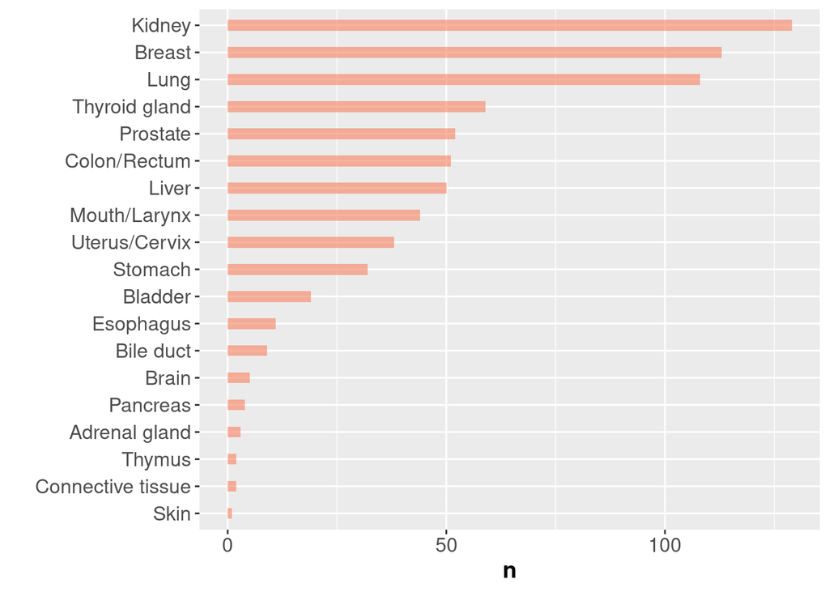

```r
metadata_normal_cases_by_tissue_plot <- metadata_normal_cases_count_by_tissue %>%
  select(tissue_simplified, n_samples_total) %>%
  unique() %>%
  mutate(tissue_simplified = fct_reorder(tissue_simplified, n_samples_total)) %>%
  ggplot( aes(x=tissue_simplified, y=n_samples_total)) +
    geom_bar(stat="identity", fill="#f68060", alpha=.6, width=.4) +
    coord_flip() +
    xlab("") +
    ylab("n") +
    guides(fill=guide_legend(title="Type of sample")) +
    #theme_bw()
    theme(plot.title =  element_text(size = 17, face="bold"), axis.title = element_text(size = 14, face="bold"), axis.text = element_text(size = 12), legend.text = element_text(size = 12), legend.title=element_text(size=14, face="bold"))

metadata_normal_cases_by_tissue_plot_file = '/home/j.aguirreplans/Projects/Scipher/SampleSize/data/out/plots/tcga_num_normal_samples_per_tissue.png'
ggsave(metadata_normal_cases_by_tissue_plot_file, plot=metadata_normal_cases_by_tissue_plot, type='cairo', dpi = 300, height=8, width = 10)
metadata_normal_cases_by_tissue_plot
```

Let’s check the number of samples for each cancer subtype:

```r
metadata_subtypes_count = metadata_df %>%
  select(participant_sample_type, cancer_subtype, sample_type_simplified) %>%
  filter(!(cancer_subtype == "")) %>%
  separate(col=cancer_subtype, into=c("cancer_type", "cancer_subtype"), sep="\\.") %>%
  filter(sample_type_simplified == "tumor") %>%
  select(-sample_type_simplified) %>%
  group_by(cancer_type) %>%
  mutate(n_samples_total=n_distinct(participant_sample_type)) %>%
  ungroup() %>%
  unique() %>%
  group_by(cancer_type, cancer_subtype, n_samples_total) %>%
  summarize(n_samples_subtype=n_distinct(participant_sample_type)) %>%
  ungroup() %>%
  unique() %>%
  arrange(desc(n_samples_total), desc(n_samples_subtype)) %>%
  as.data.frame()
metadata_subtypes_count
```

```
##    cancer_type       cancer_subtype n_samples_total n_samples_subtype
## 1         BRCA                 LumA            1095               566
## 2         BRCA                 LumB            1095               217
## 3         BRCA                Basal            1095               190
## 4         BRCA                 Her2            1095                82
## 5         BRCA               Normal            1095                41
## 6           GI                  CIN             952               599
## 7           GI                  MSI             952               126
## 8           GI                   GS             952               103
## 9           GI                 ESCC             952                78
## 10          GI                  EBV             952                27
## 11          GI               HM-SNV             952                19
## 12     GBM_LGG          G-CIMP-high             673               234
## 13     GBM_LGG                Codel             673               173
## 14     GBM_LGG     Mesenchymal-like             673                98
```

[output cut: 82 more lines]

## Data

We read the processed file:

```r
# Define and read data file
if(!(type_counts %in% c("tpm", "reads"))){
  stop("Unknown type of data")
}
tcga_file = paste(output_dir, paste("TCGA_", type_counts, ".csv", sep=""), sep='/')
tcga_df = fread(tcga_file, header=TRUE)
```

The `tcga_df` dataframe contains 11124 columns (samples) and 60660 rows (genes).

```r
tcga_df %<>% rename("Ensembl"="gene_id")
head(tcga_df[1:10,1:5])
```

```
##               Ensembl
## 1: ENSG00000000003.15
## 2:  ENSG00000000005.6
## 3: ENSG00000000419.13
## 4: ENSG00000000457.14
## 5: ENSG00000000460.17
## 6: ENSG00000000938.13
##    88215dd0-5841-44f1-9393-eefd8238cbb3.rna_seq.augmented_star_gene_counts.tsv
## 1:                                                                        3473
## 2:                                                                           2
## 3:                                                                        1591
## 4:                                                                        1263
## 5:                                                                         206
## 6:                                                                          65
##    e74f321c-217f-4bdc-ad17-f132501b5157.rna_seq.augmented_star_gene_counts.tsv
```

[output cut: 20 more lines]

```r
dim(tcga_df)
```

```
## [1] 60660 11124
```

The columns (samples) are actually file names. We select the ones present in the metadata:

```r
metadata_file_names = unique(metadata_df$file_name)
tcga_df = cbind(tcga_df$Ensembl, tcga_df %>% select(all_of(metadata_file_names)))
tcga_df %<>% rename("Ensembl"="V1")
dim(tcga_df)
```

```
## [1] 60660 11124
```

Now it contains 11124 columns (samples) and 60660 rows (genes).

### Gene pre-processing

In the gene expression dataframe, there are 60660 genes in Ensembl notation. We will transform these genes into HGNC gene symbol notation.

First we read the file `multiple_hgnc_dict_set_2022-01-01.txt`, containing gene symbols and their aliases in other notations:

```r
gene_annotations_dir = '/work/ccnr/j.aguirreplans/data/gene_annotations/data/out'
gene_dict_file = paste(gene_annotations_dir, 'multiple_hgnc_dict_set_2022-01-01.txt', sep='/')
gene_dict_df = fread(gene_dict_file) %>% unique()
gene_dict_df = gene_dict_df[!((gene_dict_df$HGNC_Symbol=="")|(gene_dict_df$alias=="")),]
gene_dict_df$HGNC_Symbol = toupper(gene_dict_df$HGNC_Symbol)
gene_dict_df$alias = toupper(gene_dict_df$alias)
gene_dict_df %<>% unique()
head(gene_dict_df)
```

```
##    HGNC_Symbol           alias
## 1:       MT-TF ENSG00000210049
## 2:       MT-TF ENST00000387314
## 3:       MT-TF       MT-TF-201
## 4:     MT-RNR1 ENSG00000211459
## 5:     MT-RNR1 ENST00000389680
## 6:     MT-RNR1     MT-RNR1-201
```

We remove the Ensembl ID part after the “.” in the gene expression dataframe:

```r
tcga_df$Ensembl = sub("\\..*", "", tcga_df$Ensembl)
head(tcga_df[1:5,1:5])
```

```
##            Ensembl
## 1: ENSG00000000003
## 2: ENSG00000000005
## 3: ENSG00000000419
## 4: ENSG00000000457
## 5: ENSG00000000460
##    62ca3ce8-77f9-4e02-ace4-af79519b53fd.rna_seq.augmented_star_gene_counts.tsv
## 1:                                                                        2026
## 2:                                                                           1
## 3:                                                                        3015
## 4:                                                                        1583
## 5:                                                                         696
##    75668632-f0c7-495b-ba34-cd4b00aa9450.rna_seq.augmented_star_gene_counts.tsv
## 1:                                                                         655
## 2:                                                                          41
## 3:                                                                        2275
## 4:                                                                        3068
## 5:                                                                         800
##    0cf58c62-a75d-413b-8ce3-4d90f4688b04.rna_seq.augmented_star_gene_counts.tsv
## 1:                                                                        3116
## 2:                                                                           6
## 3:                                                                        2860
## 4:                                                                        1580
## 5:                                                                         344
##    a622a28b-a3ac-495b-b696-2a11e0e0e2ad.rna_seq.augmented_star_gene_counts.tsv
## 1:                                                                        4305
## 2:                                                                         869
## 3:                                                                        1796
## 4:                                                                         947
## 5:                                                                         202
```

We use this dataframe to map Ensembl IDs to HGNC symbol IDs:

```r
tcga_df = inner_join(tcga_df, gene_dict_df, by=c("Ensembl"="alias"))
tcga_df = cbind((tcga_df %>% select("Ensembl", "HGNC_Symbol")), (tcga_df %>% select(-"Ensembl", -"HGNC_Symbol"))) %>% unique()
head(tcga_df[1:5,1:5])
```

```
##            Ensembl HGNC_Symbol
## 1: ENSG00000000003      TSPAN6
## 2: ENSG00000000005        TNMD
## 3: ENSG00000000419        DPM1
## 4: ENSG00000000457       SCYL3
## 5: ENSG00000000460    C1ORF112
##    62ca3ce8-77f9-4e02-ace4-af79519b53fd.rna_seq.augmented_star_gene_counts.tsv
## 1:                                                                        2026
## 2:                                                                           1
## 3:                                                                        3015
## 4:                                                                        1583
## 5:                                                                         696
##    75668632-f0c7-495b-ba34-cd4b00aa9450.rna_seq.augmented_star_gene_counts.tsv
## 1:                                                                         655
## 2:                                                                          41
## 3:                                                                        2275
## 4:                                                                        3068
## 5:                                                                         800
##    0cf58c62-a75d-413b-8ce3-4d90f4688b04.rna_seq.augmented_star_gene_counts.tsv
## 1:                                                                        3116
## 2:                                                                           6
## 3:                                                                        2860
## 4:                                                                        1580
## 5:                                                                         344
```

```r
dim(tcga_df)
```

```
## [1] 40225 11125
```

Now, we have 40161 unique HGNC symbols mapped to 40045 unique Ensembl IDs from a total of 40225 rows. The problem is that there are Ensembl IDs mapped to the same HGNC code and viceversa. So, we have to do the following procedures: - If an Ensembl ID has multiple HGNC symbols, keep only one symbol - If a HGNC symbol has multiple Ensembl IDs, calculate the median

```r
repeated_ensembl = unique(tcga_df$Ensembl[duplicated(tcga_df$Ensembl)])
length(repeated_ensembl)
```

```
## [1] 178
```

```r
repeated_ensembl_df = tcga_df[tcga_df$Ensembl %in% repeated_ensembl,][,c("Ensembl", "HGNC_Symbol")]
repeated_ensembl_df$HGNC_length = nchar(repeated_ensembl_df$HGNC_Symbol)
repeated_ensembl_df = repeated_ensembl_df[order(Ensembl, HGNC_length),]
head(repeated_ensembl_df)
```

```
##            Ensembl HGNC_Symbol HGNC_length
## 1: ENSG00000002586        CD99           4
## 2: ENSG00000002586        CD99           4
## 3: ENSG00000018607      ZNF806           6
## 4: ENSG00000018607    ZNF285CP           8
## 5: ENSG00000034239        CLXN           4
## 6: ENSG00000034239      EFCAB1           6
```

We keep the smallest symbol, and if not, the first (in alphabetical order):

```r
repeated_ensembl_distinct_df = repeated_ensembl_df %>% distinct(Ensembl, .keep_all = TRUE) %>% select(Ensembl, HGNC_Symbol)
head(repeated_ensembl_distinct_df)
```

```
##            Ensembl HGNC_Symbol
## 1: ENSG00000002586        CD99
## 2: ENSG00000018607      ZNF806
## 3: ENSG00000034239        CLXN
## 4: ENSG00000093134        VNN3
## 5: ENSG00000101898       MCTS2
## 6: ENSG00000124333       VAMP7
```

```r
hgnc_to_remove = repeated_ensembl_df$HGNC_Symbol[!(repeated_ensembl_df$HGNC_Symbol %in% repeated_ensembl_distinct_df$HGNC_Symbol)]
tcga_df %<>% filter(!(HGNC_Symbol %in% hgnc_to_remove))
```

```r
dim(tcga_df)
```

```
## [1] 40082 11125
```

```r
repeated_hgnc = unique(tcga_df$HGNC_Symbol[duplicated(tcga_df$HGNC_Symbol)])
length(repeated_hgnc)
```

```
## [1] 63
```

```r
repeated_hgnc_df = tcga_df[tcga_df$HGNC_Symbol %in% repeated_hgnc,][,c("Ensembl", "HGNC_Symbol")][order(HGNC_Symbol),]
head(repeated_hgnc_df)
```

```
##            Ensembl HGNC_Symbol
## 1: ENSG00000197976     AKAP17A
## 2: ENSG00000197976     AKAP17A
## 3: ENSG00000237801      AMD1P2
## 4: ENSG00000237801      AMD1P2
## 5: ENSG00000196433        ASMT
## 6: ENSG00000196433        ASMT
```

We calculate the median for the HGNC genes with multiple Ensembl IDs:

```r
tcga_df = subset(tcga_df, select=-Ensembl)
repeated_hgnc_aggregated = aggregate(.~HGNC_Symbol, tcga_df[tcga_df$HGNC_Symbol %in% repeated_hgnc,], median)
tcga_df = rbind(tcga_df[!(tcga_df$HGNC_Symbol %in% repeated_hgnc),], repeated_hgnc_aggregated)
dim(tcga_df)
```

```
## [1] 40019 11124
```

```r
tcga_processed_file = paste(output_dir, "TCGA_genes_processed.csv", sep='/')
fwrite(tcga_df, tcga_processed_file, sep='\t')
```

### Sample pre-processing

There are participant_sample_type IDs that are mapped to multiple files. We will merge the participant_sample_type IDs that have multiple file IDs, and substitute the file IDs with participant_sample_type IDs in the data file.

We identify the participant_sample_type IDs with multiple file IDs:

```r
mappings_tcga_df = metadata_df %>% filter(file_name %in% colnames(tcga_df)[-1]) %>% select(file_name, participant_sample_type) %>% unique()
mappings_tcga_duplicated_df = mappings_tcga_df %>% filter(participant_sample_type %in% subset(mappings_tcga_df,duplicated(participant_sample_type))$participant_sample_type)
head(mappings_tcga_duplicated_df)
```

```
##                                                                      file_name
## 1: 829d07d7-8a03-4350-8999-4ffd493f6218.rna_seq.augmented_star_gene_counts.tsv
## 2: 49432779-e2b3-4e36-b1a9-88c7c45854ff.rna_seq.augmented_star_gene_counts.tsv
## 3: 83b37bd1-fd81-4ebc-a513-449cbd1710e8.rna_seq.augmented_star_gene_counts.tsv
## 4: 24747d11-c715-48f3-821b-f6dbd6a890fb.rna_seq.augmented_star_gene_counts.tsv
## 5: df6189e5-bd61-4be2-9d31-efef56cb4739.rna_seq.augmented_star_gene_counts.tsv
## 6: db5dab56-838e-4784-a7cf-f05296e356f7.rna_seq.augmented_star_gene_counts.tsv
##    participant_sample_type
## 1:              A13J-tumor
## 2:              A0C8-tumor
## 3:              A13I-tumor
## 4:              A15K-tumor
## 5:              A26J-tumor
## 6:              A0DC-tumor
```

There are 118 participant_sample_type IDs with multiple file IDs. We calculate the median between the expression of these file IDs.

```r
genes_tcga_df = tcga_df$HGNC_Symbol
tcga_df %<>% select(-HGNC_Symbol) %>% t() %>% as.data.frame()
colnames(tcga_df) = genes_tcga_df
tcga_df = cbind(data.frame(file_name=row.names(tcga_df)), tcga_df)
tcga_df %<>% inner_join(mappings_tcga_df, by=c("file_name"="file_name"))
tcga_df %<>% relocate(file_name, participant_sample_type)
tcga_df = subset(tcga_df, select=-file_name)
tcga_participant_ids_duplicated = tcga_df[tcga_df$participant_sample_type %in% unique(mappings_tcga_duplicated_df$participant_sample_type),]
#participant_ids_aggregated = aggregate(.~participant_sample_type, tcga_participant_ids_duplicated, median)
participant_ids_aggregated = tcga_participant_ids_duplicated %>% group_by(participant_sample_type) %>% summarise(across(everything(), median, na.rm = TRUE)) %>% ungroup() %>% as.data.frame()
tcga_df = rbind(tcga_df[!(tcga_df$participant_sample_type %in% unique(mappings_tcga_duplicated_df$participant_sample_type)),], participant_ids_aggregated)
dim(tcga_df)
```

```
## [1] 10963 40020
```

```r
# We transpose the matrix
genes = colnames((tcga_df %>% select(-participant_sample_type)))
participant_sample_type_ids = tcga_df$participant_sample_type
tcga_df = t(as.matrix((tcga_df %>% select(-participant_sample_type)))) %>% as.data.frame()
colnames(tcga_df) = participant_sample_type_ids
tcga_df = cbind(data.frame(Gene=genes), tcga_df)
```

```r
tcga_processed_file = paste(output_dir, "TCGA_genes_and_samples_processed.csv", sep='/')
fwrite(tcga_df, tcga_processed_file, sep='\t')
```

The processed `tcga_df` dataframe contains 10963 columns (participant_sample_type IDs) and 40019 rows (genes).

```r
head(tcga_df[1:10,1:5])
```

```
##              Gene A1PB-tumor A10E-tumor A1JB-tumor A204-normal
## TSPAN6     TSPAN6       2026        655       3116        4305
## TNMD         TNMD          1         41          6         869
## DPM1         DPM1       3015       2275       2860        1796
## SCYL3       SCYL3       1583       3068       1580         947
## C1ORF112 C1ORF112        696        800        344         202
## FGR           FGR       1540        320        399         747
```